# Essential Statistics

PhD+ 2024: Data Literacy in R  
Session 4

Clay Ford, UVA Library

## Load data

All data used in this slides is available as a `.Rdata` file at the following link:

https://github.com/clayford/phdplus2024/raw/main/session_4/session_4.Rdata

```r
load(url("https://github.com/clayford/phdplus2024/raw/main/session_4/session_4.Rdata"))
```

## Calculating proportions

Cross tabulation of group (aspirin/placebo) and myocardial infarction (yes/no)

```r
mi
```

```
         myocardial infarction
group        no yes
  placebo 10845 189
  aspirin 10933 104
```

The proportions function calculates proportions across a set margin. Proportion of subjects who did and did not experience myocardial infarction.

```r
mi_tab <- proportions(mi, margin = "group")
mi_tab
```

```
         myocardial infarction
group            no        yes
  placebo 0.9828711 0.01712887
  aspirin 0.9905771 0.00942285
```

## Relative versus absolute difference

Absolute difference in proportions: about -0.008 (risk difference)

```r
mi_tab["aspirin", "yes"] - mi_tab["placebo","yes"]
```

```
[1] -0.007706024
```

Relative difference in proportions: about 0.55 (risk ratio)

```r
mi_tab["aspirin", "yes"] / mi_tab["placebo","yes"]
```

```
[1] 0.550115
```

```r
1 - (mi_tab["aspirin", "yes"] / mi_tab["placebo","yes"])
```

```
[1] 0.449885
```

## `xtabs()`

`xtabs()` is useful for creating cross tabulations from rows of a data frame.

```r
xtabs(~ hsdistrict + fp, data = homes)
```

```
                   fp
hsdistrict            No  Yes
  Albemarle         2752 9810
  Monticello        4033 6545
  Western Albemarle 2494 6868
```

Can pipe output into `proportions()`. Proportion of homes with and without fireplaces in each high school district.

```r
# all rows sum to 1
xtabs(~ hsdistrict + fp, data = homes) |>
  proportions(margin = "hsdistrict")
```

```
                   fp
hsdistrict                 No       Yes
  Albemarle         0.2190734 0.7809266
  Monticello        0.3812630 0.6187370
  Western Albemarle 0.2663961 0.7336039
```

Note: Use `Ctrl+Shift+M` (Win) or `Cmd+Shift+M` (Mac) to insert pipe operator. Requires R version 4.1 or higher.

## 3D tables

Adding a 3rd variable creates a three dimensional table. Cross tab of hsdistrict and fp *stratified* by cooling.

```r
xtabs( ~ hsdistrict + fp + cooling, data = homes)
```

```
, , cooling = No Central Air

                   fp
hsdistrict            No  Yes
  Albemarle          372  343
  Monticello        1040  477
  Western Albemarle  647  381

, , cooling = Central Air

                   fp
hsdistrict            No  Yes
  Albemarle         2380 9467
  Monticello        2993 6068
  Western Albemarle 1847 6487
```

## 3D tables

Again we can pipe into `proportions()`. Proportion of homes with and without fireplaces in each high school district, stratified by cooling.

```r
# all rows sum to 1
xtabs( ~ hsdistrict + fp + cooling, data = homes) |>
  proportions(margin = c("hsdistrict", "cooling"))
```

```
, , cooling = No Central Air

                   fp
hsdistrict                 No       Yes
  Albemarle         0.5202797 0.4797203
  Monticello        0.6855636 0.3144364
  Western Albemarle 0.6293774 0.3706226

, , cooling = Central Air

                   fp
hsdistrict                 No       Yes
  Albemarle         0.2008947 0.7991053
  Monticello        0.3303167 0.6696833
  Western Albemarle 0.2216223 0.7783777
```

## Uncertainty

Sometimes we can collect all the data in a population (eg, Albemarle County real estate data). The mean of the data is the mean. There is no uncertainty.

Sometimes we can only collect a sample (eg, voters, trees, cows). Hopefully it’s a *random sample*. The mean of the sample data is *not* the mean of the entire population. It is an *estimate*.

We often use the estimate as our best guess at the population mean. How uncertain is this estimate?

We usually try to assess this with *standard errors* and *confidence intervals*.

## Standard Errors

Imagine randomly sampling 30 UVA students, weighing their backbacks, and taking the mean weight. And then sampling 30 more students and getting another mean. And again, and again, thousands of times, getting more means.

Now calculate the standard deviation of those means. That’s the *standard error*.

The standard deviation of the sample means summarizes the uncertainty of our sample mean.

In practice, we don’t take thousands of means. We take one and we usually calculate standard error using a formula such as $SD_{\text{sample}}/\sqrt{n}$.

For example, a [study](https://www.sciencedirect.com/science/article/pii/S2314853516300555) estimated the mean weight of chicken eggs to be about 55.02g with a standard error of 0.40 when the chicken was 25 weeks old.

**Important**

Be cautious of interpreting estimates presented without standard errors.

## The Central Limit Theorem

Previously we saw distributions of *raw data* for which the standard deviation was not a good measure of spread.

However it turns out the distribution of sample means calculated from most distributions is fairly symmetric. This is the *Central Limit Theorem*. This means we can be fairly confident about standard error estimates.

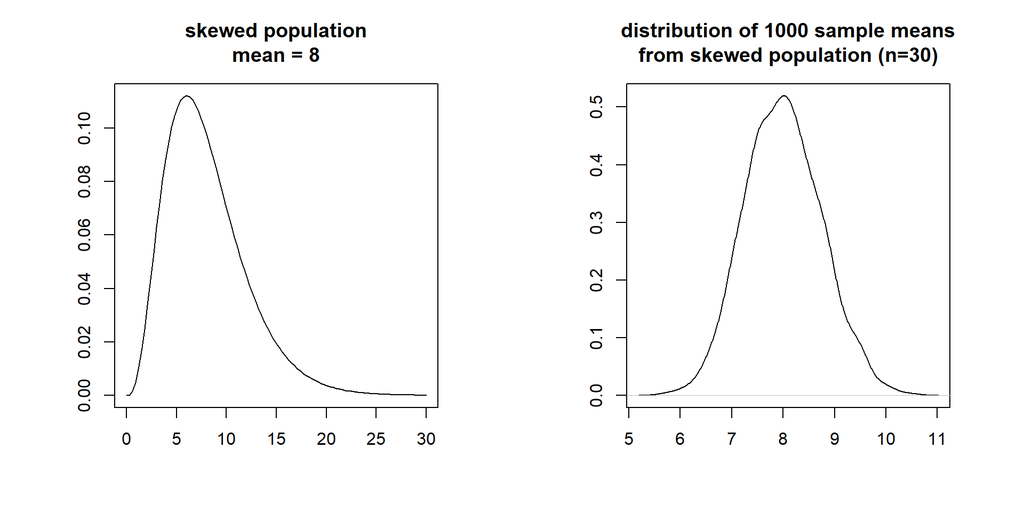

## Confidence Intervals

Adding and subtracting standard errors to our estimate forms an interval of what we might say is a reasonable range that contains the true population value.

The most common interval calculated is the *95% confidence interval* (CI).

We say “95%” because the method should work 95% of the time based on the number of standard errors we add/subtract to create the interval.

We call it “confidence” because we are confident in the method.

## Confident in the process

If we were to take thousands of samples and calculate thousands of 95% confidence intervals, about 95% of the intervals should contain the true value.

The 95% confidence interval on the number of trees (in trillions) was [2.94, 3.14]. That interval either contains the true number or it does not.

**Important**

A confidence interval is *not* a probability interval. Do not say there is a 95% probability the value is between the lower and upper bounds.

## Confidence interval for mean

Calculate the mean and a 95% confidence interval for “Mass.g” in the rats data set using `smean.cl.normal()` function from the Hmisc package.

```r
Hmisc::smean.cl.normal(rats$Mass.g)
```

```
    Mean    Lower    Upper
41.81421 40.97943 42.64898
```

Can also use the base R `t.test()` function to get the CI:

```r
t.test(rats$Mass.g)$conf.int
```

```
[1] 40.97943 42.64898
attr(,"conf.level")
[1] 0.95
```

## Confidence interval for proportion

The variable “Pterygodermatites.dipodomis” indicates whether a sample was positive for the presence of Pterygodermatites dipodomis (1 = positive, 0 = negative). Calculate the proportion of rats with this parasite and a 95% confidence interval using the `prop.test()` function.

```r
table(rats$Pterygodermatites.dipodomis)
```

```
  0   1
131  70
```

```r
prop.test(x = 70, n = 70 + 131)$conf.int
```

```
[1] 0.2834667 0.4189548
attr(,"conf.level")
[1] 0.95
```

## CIs for group means

Mean serotonin levels in locusts captured for 0, 1, and 2 hours. `aggregate()` returns a data frame. `tapply()` returns a list.

```r
aggregate(serotoninLevel ~ treatmentTime, data = locusts,
          Hmisc::smean.cl.normal)
```

```
  treatmentTime serotoninLevel.Mean serotoninLevel.Lower serotoninLevel.Upper
1             0            6.360000             2.912042             9.807958
2             1            8.040000             4.489190            11.590810
3             2           10.820000             7.008819            14.631181
```

```r
tapply(locusts$serotoninLevel, locusts$treatmentTime, Hmisc::smean.cl.normal)
```

```
$`0`
    Mean    Lower    Upper
6.360000 2.912042 9.807958

$`1`
    Mean    Lower    Upper
 8.04000  4.48919 11.59081

$`2`
     Mean     Lower     Upper
10.820000  7.008819 14.631181
```

## Plot CIs for group means

The `stat_summary()` function with `fun.data = mean_cl_normal` plots means and 95% CIs.

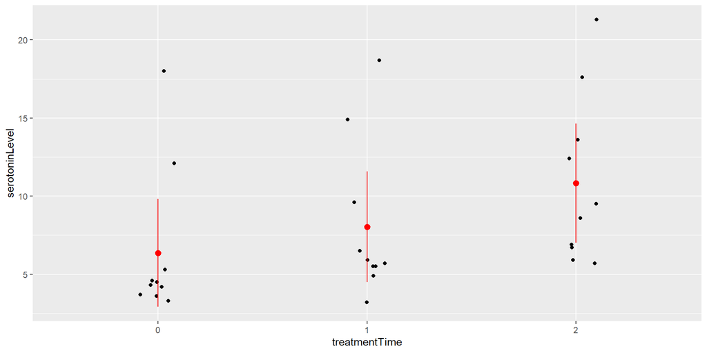

```r
library(ggplot2)
ggplot(locusts) +
  aes(x = treatmentTime, y = serotoninLevel) +
  geom_jitter(height = 0, width = 0.1) +
  stat_summary(fun.data = mean_cl_normal, colour = "red")
```

## Bootstrap confidence intervals

Treat random sample like a surrogate for the population and resample from it with replacement, and then calculate your statistic(s) on the new sample. Repeat many times to generate many replications and use the replications to estimate standard error and/or a confidence interval.

```r
bs_out <- replicate(n = 10000, expr = {
  bstrap <- sample(trees$Height, replace = TRUE)
  median(bstrap)
  })
quantile(bs_out, probs = c(0.025, 0.975))
```

```
 2.5% 97.5%
   74    80
```

## Bootstrap confidence intervals

Can also use the {boot} package that comes with R. Need to supply a function. The “bca” interval is a bias-corrected confidence interval

```r
library(boot)
md <- function(x, i)median(x[i])
bs_out2 <- boot(data = trees$Height, statistic = md, R = 10000)
boot.ci(bs_out2, type = c("perc", "bca"))
```

```
BOOTSTRAP CONFIDENCE INTERVAL CALCULATIONS
Based on 10000 bootstrap replicates

CALL :
boot.ci(boot.out = bs_out2, type = c("perc", "bca"))

Intervals :
Level     Percentile            BCa
95%   (74, 80 )   (72, 78 )
Calculations and Intervals on Original Scale
```

## Hypothesis testing and p-values

Let’s say we believe a coin is fair and lands heads 50% of the time.

We flip it 20 times and get 18 heads. That’s 18/20 = 0.90, or 90%.

If the coin was really fair, what is the probability of getting 18 *or more* heads?

The answer is about 0.0002. That’s a *p-value*.

That’s a small probability and leads us to reject the belief that the coin is fair.

What we just described is an example of a *hypothesis test*.

## Hypothesis testing and p-values

Hypothesis testing estimates the probability of obtaining the data we collected, or more extreme data, under the assumption of some hypothesis (usually a null/no effect hypothesis).

What is the probability a cow painted like a zebra would have 55 *or fewer* fly bites than an unpainted cow which had 128, *assuming the paint job had no effect*? The authors state p < 0.0001.

Historically, p-values < 0.05 have been interpreted as “statistically significant”, though many statisticians are [now calling to abolish that threshold and the phrase “statistically significant”](https://www.tandfonline.com/doi/full/10.1080/00031305.2019.1583913).

Nevertheless, p-values have been published, and will likely continue to be published, so it pays to know what they mean.

**Tip**

When you see a p-value, think “probability of the data, or more extreme data, assuming a null hypothesis was true.”

## p-values are slippery

P-values are often misinterpreted and misused.

1. They *do not* measure the probability the null hypothesis is true or that the data were produced by random chance alone.
2. They *do not* justify proof of something because they’re less than 0.05.
3. They *do not* prove the null hypothesis because they’re greater than 0.05.
4. They *do not* measure the size of an effect or the importance of a result.

See The American Statistical Association’s [special issue](https://www.tandfonline.com/doi/full/10.1080/00031305.2019.1583913) on p-values.

**Important**

P-values should not be revered as the final word in any analysis.

## Hypothesis testing

Say I flip a coin and get 16 heads. What is the probability of getting 16 or more heads if the coin is fair?

```r
binom.test(x = 16, n = 20, p = 0.5, alternative = "greater")
```

```
    Exact binomial test

data:  16 and 20
number of successes = 16, number of trials = 20, p-value = 0.005909
alternative hypothesis: true probability of success is greater than 0.5
95 percent confidence interval:
 0.5989719 1.0000000
sample estimates:
probability of success
                   0.8
```

The p-value is the probability of 16 or more heads assuming coin is fair

## Comparing two means

Do long spikes on a horned lizard (mm) help protect from being eaten by shrikes, a type of bird that skewers its victims on thorns to eat later? The lizards data set contains measurements of the length of lizard horns for two groups: those that were alive and those that had been killed and skewered.

```r
t.test(horn_length ~ survival, data = lizards)
```

```
    Welch Two Sample t-test

data:  horn_length by survival
t = -4.2634, df = 40.372, p-value = 0.0001178
alternative hypothesis: true difference in means between group killed and group living is not equal to 0
95 percent confidence interval:
 -3.381912 -1.207092
sample estimates:
mean in group killed mean in group living
            21.98667             24.28117
```

The probability of seeing a difference in means this big or bigger if there really was no difference is about 0.00012.

## Comparing more than two means

Are the mean serotonin levels in captured locusts for 0, 1, and 2 hours different? The null is no difference in means

```r
# ANOVA
m <- aov(serotoninLevel ~ treatmentTime, data = locusts)
summary(m)
```

```
              Df Sum Sq Mean Sq F value Pr(>F)
treatmentTime  2  101.5   50.74   1.996  0.155
Residuals     27  686.3   25.42
```

The probability of seeing differences in means this big or bigger if all three were the same is about 0.15.

## Comparing two categorical variables

Is habitat related to whether or not a rat has Pterygodermatites dipodomis?

```r
tab <- table(rats$Habitat, rats$Pterygodermatites.dipodomis)
tab
```

```
         0  1
  urban 64 45
  wild  67 25
```

Null: habitat and Pterygodermatites dipodomis are independent

```r
# chi-square test
chisq.test(tab)
```

```
    Pearson's Chi-squared test with Yates' continuity correction

data:  tab
X-squared = 3.7769, df = 1, p-value = 0.05197
```

The probability of seeing data like this (or more extreme) if the two variables are independent is about 0.05.

## Comparing two categorical variables

Can also directly compare proportions. Null: proportions are no different.

```r
addmargins(tab)
```

```
          0   1 Sum
  urban  64  45 109
  wild   67  25  92
  Sum   131  70 201
```

```r
prop.test(x = c(45, 25), n = c(109, 92))
```

```
    2-sample test for equality of proportions with continuity correction

data:  c(45, 25) out of c(109, 92)
X-squared = 3.7769, df = 1, p-value = 0.05197
alternative hypothesis: two.sided
95 percent confidence interval:
 0.001444388 0.280765425
sample estimates:
   prop 1    prop 2
0.4128440 0.2717391
```

Notice the p-value is the same as the p-value from the chi-square test.

## Power and sample size

Power and sample size calculations should be carried out before you collect data. Example study: two groups (control and treated) will be timed to complete a task. A 5-second difference in mean time is considered important and a standard deviation of 5 seconds is assumed. How much power do we have with 15 subjects in each group?

```r
power.t.test(n = 15, delta = 5, sd = 5, sig.level = 0.05)
```

```
     Two-sample t test power calculation

              n = 15
          delta = 5
             sd = 5
      sig.level = 0.05
          power = 0.752921
    alternative = two.sided

NOTE: n is number in *each* group
```

We have probability of 0.75 of successfully rejecting null hypothesis (assuming the alternative it true) with 15 subjects in each group.

## Power and sample size

Estimate sample size if we desire power of 0.90.

```r
power.t.test(power = 0.9, delta = 5, sd = 5, sig.level = 0.05)
```

```
     Two-sample t test power calculation

              n = 22.0211
          delta = 5
             sd = 5
      sig.level = 0.05
          power = 0.9
    alternative = two.sided

NOTE: n is number in *each* group
```

To have probability of 0.90 to successfully reject null hypothesis (assuming the alternative is true) we should sample at least 23 subjects in each group.

## Sample size for desired precision

How many subjects should we sample if we want to estimate a difference in means with a precision of 4 (i.e., within 2 seconds of true difference in means)?

```r
presize::prec_meandiff(delta = 5, sd1 = 5, conf.width = 4, var = "equal")
```

```
     sample size for mean difference with equal variance

  delta sd1 sd2       n1       n2 conf.width conf.level lwr upr
1     5   5   5 49.24563 49.24563          4       0.95   3   7
```

We need at least 50 subjects in each group.

## Non-parametric methods

Non-parametric methods do not assume that the data has a specific distribution. Sometimes they’re called “distribution free” methods.

The non-parametric version of the t-test is called the *Wilcoxon* test. It assumes both groups have the same distribution. Rejecting the test implies the distributions are different.

```r
wilcox.test(horn_length ~ survival, data = lizards, conf.int = TRUE)
```

```
    Wilcoxon rank sum test with continuity correction

data:  horn_length by survival
W = 1181.5, p-value = 2.366e-05
alternative hypothesis: true location shift is not equal to 0
95 percent confidence interval:
 -3.200076 -1.300067
sample estimates:
difference in location
             -2.200031
```

## Non-parametric methods

The non-parametric version of the one way ANOVA is called the *Kruskal-Wallis* test. It assumes all groups have the same distribution. Rejecting the test implies at least one of the distributions is different.

```r
kruskal.test(serotoninLevel ~ treatmentTime, data = locusts)
```

```
    Kruskal-Wallis rank sum test

data:  serotoninLevel by treatmentTime
Kruskal-Wallis chi-squared = 8.8394, df = 2, p-value = 0.01204
```

## Summarizing two sets of values

Below is a scatterplot of 200 randomly sampled homes from Albemarle County comparing total value to finished sq ft. How can we summarize this relationship?

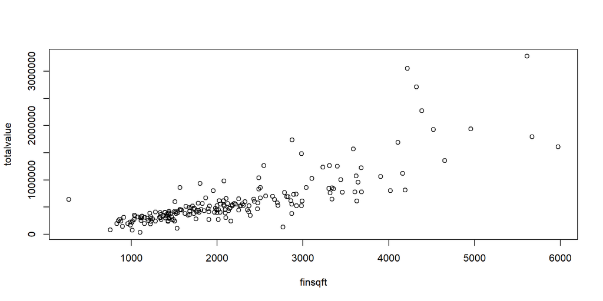

```r
set.seed(23)
i <- sample(nrow(homes), size = 200)
samp_d <- homes[i,]
plot(totalvalue ~ finsqft, data = samp_d)
```

## Correlation

Correlation is a single value that can (sometimes) summarize a relationship between two sets of numeric data.

Correlation is unitless and ranges from -1 to 1. It expresses how close dots fall along a line. [See this useful Wikipedia illustration](https://en.wikipedia.org/wiki/Correlation_and_dependence#/media/File:Correlation_examples2.svg)

**Pearson** correlation measures linear association.  
**Spearman** *rank* correlation can measure non-linear association such as curved lines.

The correlation of the data in the previous plot can be calculated as follows:

```r
cor(samp_d$finsqft, samp_d$totalvalue, method = "pearson")
```

```
[1] 0.8034409
```

```r
cor(samp_d$finsqft, samp_d$totalvalue, method = "spearman")
```

```
[1] 0.8427251
```

## Correlation warning

Correlations near 0 do not mean there is no relationship. Observe the following, courtesy of [The Datasaurus Dozen](https://github.com/jumpingrivers/datasauRus). Lesson: plot your data.

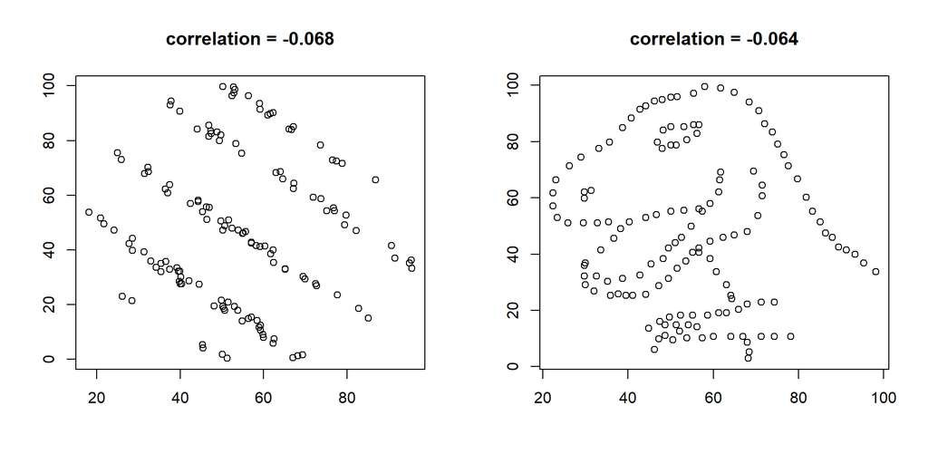

## Simple Regression

This relationship could be summarized, or modeled, with a straight line.

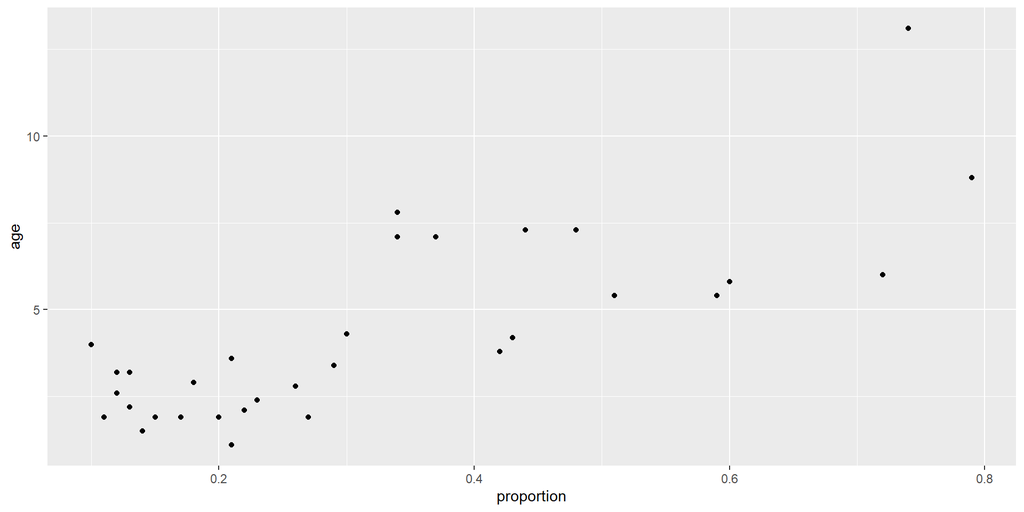

```r
ggplot(lions) +
  aes(x = proportion, y = age) +
  geom_point()
```

## Simple regression

A straight line has the formula $y = \beta_0 + \beta_1x$. Simple regression estimates $\beta_0$ (the intercept) and $\beta_1$ (the slope).

```r
m <- lm(age ~ proportion, data = lions)
summary(m)
```

```
Call:
lm(formula = age ~ proportion, data = lions)

Residuals:
    Min      1Q  Median      3Q     Max
-2.5449 -1.1117 -0.5285  0.9635  4.3421

Coefficients:
            Estimate Std. Error t value Pr(>|t|)
(Intercept)   0.8790     0.5688   1.545    0.133
proportion   10.6471     1.5095   7.053 7.68e-08 ***
---
Signif. codes:  0 '***' 0.001 '**' 0.01 '*' 0.05 '.' 0.1 ' ' 1

Residual standard error: 1.669 on 30 degrees of freedom
Multiple R-squared:  0.6238,    Adjusted R-squared:  0.6113
F-statistic: 49.75 on 1 and 30 DF,  p-value: 7.677e-08
```

Best fitting line: age of lion = 0.8790 + 10.6471 * proportion

## Plot with fitted line

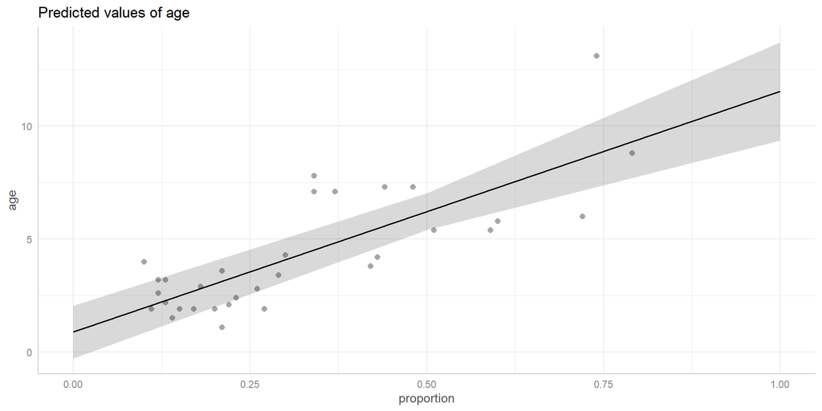

```r
library(ggeffects)
ggpredict(m) |>
  plot(add.data = TRUE)
```

## Uncertainty in fitted line

The estimates for $\beta_0$ (the intercept) and $\beta_1$ are uncertain. Get confidence intervals using `confint()` on the model object.

```r
confint(m)
```

```
                 2.5 %    97.5 %
(Intercept) -0.2826733  2.040686
proportion   7.5643082 13.729931
```

Estimated age of lion increases by about .756 to 1.37 years for each 0.1 increase in proportion of dark pigmentation on nose.

## Uncertainty in predicted values

Use `predict()` on the model object to get predicted values and associated confidence intervals.

Expected mean age of lions with 0.3 proportion of dark pigmentation on nose.

```r
predict(m, newdata = data.frame(proportion = 0.3), interval = "confidence")
```

```
       fit      lwr     upr
1 4.073142 3.466804 4.67948
```

Expected age of a specific lion with 0.3 proportion of dark pigmentation on nose.

```r
predict(m, newdata = data.frame(proportion = 0.3), interval = "prediction")
```

```
       fit       lwr     upr
1 4.073142 0.6115538 7.53473
```

This interval is much more uncertain.

## Residuals

Residuals = observed response - predicted response.

```r
# residuals: obs - fitted
head(lions$age - fitted(m))
```

```
          1           2           3           4           5           6
-2.01490129 -0.86960293 -0.15018934 -0.06313173  0.44333946  0.93686827
```

Or use `residuals()`:

```r
head(residuals(m))
```

```
          1           2           3           4           5           6
-2.01490129 -0.86960293 -0.15018934 -0.06313173  0.44333946  0.93686827
```

Residuals are used to assess linear regression assumptions.

## Regression assumptions

Linear regression assumes residuals are normally distributed and have constant variance (i.e., they’re not systematically too high or too low).

Residuals versus fitted value plot is useful to assess this (next slide).

Hopefully all residuals are evenly scattered around 0. The red line is meant to reveal any patterns in the residuals. Hopefully there are none.

The plot on the next slide shows fitted values becoming more uncertain with higher ages.

## Residuals versus fitted values

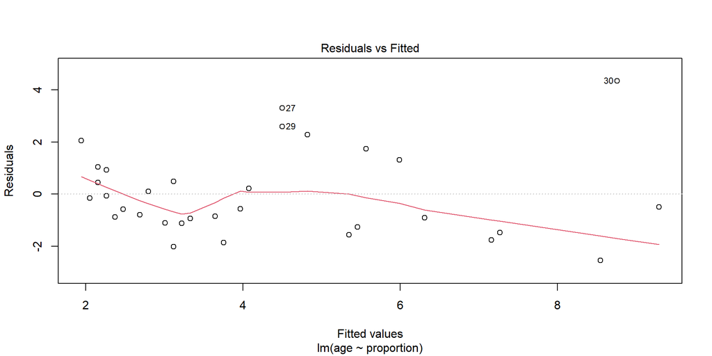

```r
plot(m, which = 1)
```

## Addressing violations of assumptions

If residuals are not evenly scattered or exhibit patterns then the straight line model is probably not a good model.

Sometimes a log transformation on the response and/or predictor variables can help.

Sometimes a non-linear model can help.

Sometimes there may not be a relationship to model.

## Fitting a non-linear model

Regression splines allows us to fit non-linear effects. Use the `ns()` function from the {splines} package that comes with R. Set `df` to determine wiggle of line. Higher means more wiggle. But more wiggle requires more data.

```r
library(splines)
m2 <- lm(age ~ ns(proportion, df = 3), data = lions)
summary(m2)
```

```
Call:
lm(formula = age ~ ns(proportion, df = 3), data = lions)

Residuals:
    Min      1Q  Median      3Q     Max
-2.4350 -1.0783 -0.3455  0.7398  4.5366

Coefficients:
                        Estimate Std. Error t value Pr(>|t|)
(Intercept)               2.5848     0.7894   3.275  0.00282 **
ns(proportion, df = 3)1   4.3045     1.3563   3.174  0.00364 **
ns(proportion, df = 3)2   5.1109     1.9061   2.681  0.01215 *
ns(proportion, df = 3)3   6.4587     1.1327   5.702 4.09e-06 ***
---
Signif. codes:  0 '***' 0.001 '**' 0.01 '*' 0.05 '.' 0.1 ' ' 1

Residual standard error: 1.684 on 28 degrees of freedom
Multiple R-squared:  0.6423,    Adjusted R-squared:  0.604
F-statistic: 16.76 on 3 and 28 DF,  p-value: 1.984e-06
```

The summary is hopeless to interpret.

## Plot with fitted line

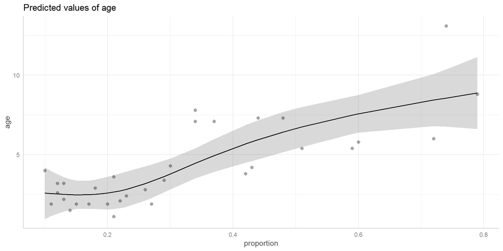

```r
library(ggeffects)
ggpredict(m2) |>
  plot(add.data = TRUE)
```

## Compare models

Can use a partial F test to compare models. Implemented with the `anova()` function. Null: models are no different.

```r
anova(m, m2)
```

```
Analysis of Variance Table

Model 1: age ~ proportion
Model 2: age ~ ns(proportion, df = 3)
  Res.Df    RSS Df Sum of Sq      F Pr(>F)
1     30 83.543
2     28 79.437  2     4.106 0.7236 0.4938
```

Fail to reject. It appears the straight line model is just as good as the more complex model. We might be happy about this because the straight line model is easier to interpret.

## Resources for further study

All of these are available through the UVA library and include lots of examples.

- Data Analysis and Graphics Using R (Maindonald and Braun)
- Using R for Introductory Statistics (Verzani)
- A Handbook of Statistical Analyses Using R (Hothorn and Everitt)
- An Introduction to Statistical Learning (James, et al)

[figure not shown]

clayford@virginia.edu | GitHub [@clayford](https://github.com/clayford)